# Cohort Retention Story (v1.2)

## Executive Decision This Supports

Which first-order product families should be prioritized for retention tests (replenishment + returns mitigation), based on M2 logo retention and net revenue proxy?

## Frozen Definitions and Limits

- Driver: `first_product_family` only
- Horizon: `H=6` (`months_since_first` in 0..6 full grid)
- Cohort universe: non-guest customers with >=1 valid purchase
- Net retention proxy: `sum(net_revenue_proxy_total_t) / sum(gross_revenue_valid_t0)`
- Chart 2 excludes cohorts with baseline denominator = 0

```
           table  rows
0         chart1   175
1  chart2_curves   175
2         chart3     8
```

## Chart 1 - Logo Retention Heatmap

Each cell is a **logo retention rate** for one `(cohort_month, months_since_first)` pair.

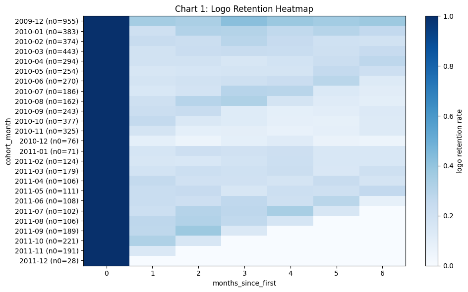

**Chart 1 caption**

- Cell value = **logo retention rate** (`mean(is_retained_logo)`) at that cohort-month position.
- Missing cells are **right-censored** or suppressed; **missing ? 0**.
- Dataset scope: both sheets (`Year 2009-2010` + `Year 2010-2011`), global range `2009-12` to `2011-12`.

## Chart 2: Net retention proxy curves (3 cohorts max)

**Formula:** `net_retention_proxy(c,t) = sum(net_revenue_proxy_total for cohort c at month t) / denom_month0_gross_valid(c)`.

Denominator guard: cohorts require `denom_month0_gross_valid > 0` and `n_customers_m0 >= MIN_COHORT_N`. Right-censoring: unobserved months are masked in chart as `NA` (not treated as `0`).

```
Selection Note
Eligibility: n0 >= MIN_COHORT_N (50), denom_month0_gross_valid > 0, cohort_period <= max_observed_month - H
Ranking signal: M2 logo retention
Selection: bottom/mid/top by M2 logo retention
Plot-size preference: n0 >= MIN_PLOT_COHORT_N (200)
MIN_COHORT_N=50, MIN_PLOT_COHORT_N=200, used_fallback=False, plot_pool_count=10
```

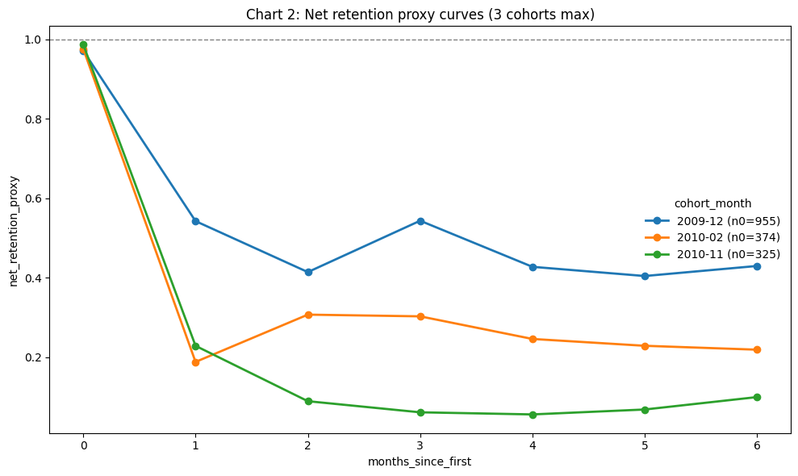

```
Selected cohorts table (MIN_COHORT_N=50, MIN_PLOT_COHORT_N=200)
```

|  | cohort_month | n0 | denom_month0_gross_valid | m2_logo_retention | m2_net_retention_proxy | m6_net_retention_proxy | plot_floor_pass |
| --- | --- | --- | --- | --- | --- | --- | --- |
| 0 | 2010-11 | 325 | 154059.730 | 0.092308 | 0.089873 | 0.100219 | True |
| 1 | 2010-02 | 374 | 170434.884 | 0.224599 | 0.307553 | 0.219399 | True |
| 2 | 2009-12 | 955 | 686654.160 | 0.334031 | 0.414531 | 0.429931 | True |

## Chart 3: M2 retention by first_product_family

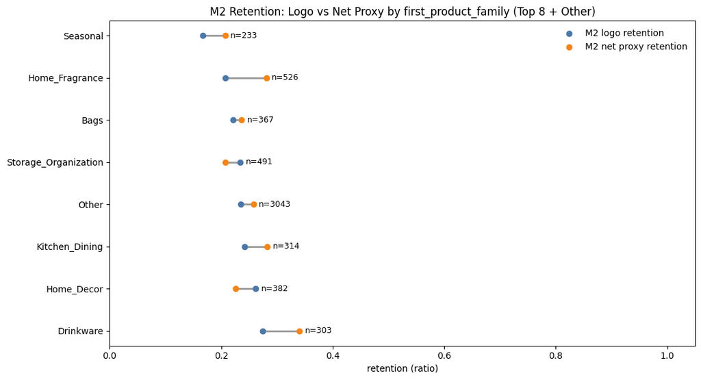

```
Refund-drag signal (top 2 by net minus logo at M2): Home_Decor (-3.6pp); Storage_Organization (-2.7pp)
```

```
Wrote C:\Users\halol\Desktop\revops\data_processed\memo_numbers.json
```

## Appendix: Top Products Driving Net Proxy

How to use this table:

- Start with rank_priority target families (1..3), then scan SKUs with most negative `delta_net_proxy_vs_family_pp` for returns/credits mitigation.
- Pair those with high `share_of_family_m0_gross_pct` to prioritize high-impact fixes first.
- Use `m2_logo_retention_observed` and `m2_net_retention_proxy_observed` jointly: repeat weakness vs value drag require different plays.

```
Source: data_processed/appendix_top_products_in_chart3_targets.csv

Family: Bags (rows=10)
```

|  | sku | description | n_customers_m0 | m0_gross_valid | m2_logo_retention_observed | m2_net_retention_proxy_observed | delta_net_proxy_vs_family_pp | share_of_family_m0_gross_pct |
| --- | --- | --- | --- | --- | --- | --- | --- | --- |
| 0 | 85099B | JUMBO BAG RED WHITE SPOTTY | 147 | 9223.08 | 0.263889 | 0.267878 | 3.154139 | 26.175600 |
| 1 | 85099C | JUMBO BAG BAROQUE BLACK WHITE | 74 | 4108.81 | 0.175676 | 0.276121 | 3.978401 | 11.661025 |
| 2 | 85099F | JUMBO BAG STRAWBERRY | 72 | 3572.24 | 0.305556 | 0.400212 | 16.387459 | 10.138210 |
| 3 | 21931 | JUMBO STORAGE BAG SUKI | 80 | 3032.61 | 0.253165 | 0.196781 | -3.955599 | 8.606711 |
| 4 | 20728 | LUNCH BAG CARS BLUE | 78 | 2946.75 | 0.311688 | 0.172598 | -6.373856 | 8.363036 |
| 5 | 22386 | JUMBO BAG PINK WITH WHITE SPOTS | 75 | 2768.43 | 0.219178 | 0.227012 | -0.932506 | 7.856954 |
| 6 | 20727 | LUNCH BAG BLACK SKULL. | 64 | 2740.70 | 0.370968 | 0.273801 | 3.746403 | 7.778255 |
| 7 | 21928 | JUMBO BAG SCANDINAVIAN PAISLEY | 55 | 2432.11 | 0.345455 | 0.344863 | 10.852634 | 6.902460 |
| 8 | 20726 | LUNCH BAG WOODLAND | 49 | 2318.50 | 0.354167 | 0.261130 | 2.479299 | 6.580028 |
| 9 | 22411 | JUMBO SHOPPER VINTAGE RED PAISLEY | 52 | 2092.18 | 0.235294 | 0.194710 | -4.162740 | 5.937720 |

```
Family: Home_Fragrance (rows=10)
```

|  | sku | description | n_customers_m0 | m0_gross_valid | m2_logo_retention_observed | m2_net_retention_proxy_observed | delta_net_proxy_vs_family_pp | share_of_family_m0_gross_pct |
| --- | --- | --- | --- | --- | --- | --- | --- | --- |
| 10 | 85123A | WHITE HANGING HEART T-LIGHT HOLDER | 192 | 16596.40 | 0.210526 | 0.416303 | 13.549959 | 55.407178 |
| 11 | 21733 | RED HANGING HEART T-LIGHT HOLDER | 63 | 2152.30 | 0.209677 | 0.244308 | -3.649556 | 7.185466 |
| 12 | 71459 | HANGING JAM JAR T-LIGHT HOLDER | 38 | 2132.80 | 0.157895 | 0.132425 | -14.837780 | 7.120365 |
| 13 | 72741 | GRAND CHOCOLATECANDLE | 63 | 1958.40 | 0.145161 | 0.103597 | -17.720623 | 6.538130 |
| 14 | 84949 | SILVER HANGING T-LIGHT HOLDER | 38 | 1528.20 | 0.131579 | 0.121221 | -15.958188 | 5.101905 |
| 15 | 22178 | VICTORIAN GLASS HANGING T-LIGHT | 55 | 1471.99 | 0.207547 | 0.234524 | -4.627861 | 4.914247 |
| 16 | 84978 | HANGING HEART JAR T-LIGHT HOLDER | 50 | 1096.78 | 0.180000 | 0.143124 | -13.767877 | 3.661606 |
| 17 | 21122 | SET/10 PINK SPOTTY PARTY CANDLES | 38 | 1077.50 | 0.210526 | 0.121717 | -15.908567 | 3.597240 |
| 18 | 84755 | COLOUR GLASS T-LIGHT HOLDER HANGING | 39 | 1035.40 | 0.153846 | 0.340375 | 5.957167 | 3.456689 |
| 19 | 21124 | SET/10 BLUE SPOTTY PARTY CANDLES | 39 | 903.75 | 0.179487 | 0.096404 | -18.439946 | 3.017175 |

```
Family: Seasonal (rows=9)
```

|  | sku | description | n_customers_m0 | m0_gross_valid | m2_logo_retention_observed | m2_net_retention_proxy_observed | delta_net_proxy_vs_family_pp | share_of_family_m0_gross_pct |
| --- | --- | --- | --- | --- | --- | --- | --- | --- |
| 20 | 22086 | PAPER CHAIN KIT 50'S CHRISTMAS | 81 | 6123.10 | 0.273973 | 0.327518 | 12.064626 | 50.570154 |
| 21 | 22910 | PAPER CHAIN KIT VINTAGE CHRISTMAS | 57 | 1876.30 | 0.169811 | 0.216872 | 1.000021 | 15.496200 |
| 22 | 22734 | SET OF 6 RIBBONS VINTAGE CHRISTMAS | 36 | 1122.71 | 0.259259 | 0.258615 | 5.174357 | 9.272365 |
| 23 | 22130 | PARTY CONE CHRISTMAS DECORATION | 32 | 750.51 | 0.156250 | 0.310085 | 10.321315 | 6.198397 |
| 24 | 22952 | 60 CAKE CASES VINTAGE CHRISTMAS | 41 | 536.40 | 0.166667 | 0.206379 | -0.049267 | 4.430081 |
| 25 | 22593 | CHRISTMAS GINGHAM STAR | 30 | 453.88 | 0.148148 | 0.249696 | 4.282378 | 3.748556 |
| 26 | 22909 | SET OF 20 VINTAGE CHRISTMAS NAPKINS | 38 | 446.25 | 0.257143 | 0.249316 | 4.244383 | 3.685540 |
| 27 | 22577 | WOODEN HEART CHRISTMAS SCANDINAVIAN | 32 | 427.10 | 0.192308 | 0.293284 | 8.641222 | 3.527382 |
| 28 | 22578 | WOODEN STAR CHRISTMAS SCANDINAVIAN | 32 | 371.88 | 0.160000 | 0.278842 | 7.197040 | 3.071325 |

## Interpretation Guardrails

- Descriptive analytics only; no causal claims.
- Wholesale-like sensitivity remains a QA table check (Gate C), not a chart.
- Exactly 3 charts are included in this notebook.